# Data manipulation and cleaning

Tad Dallas

## Data

Data is life. We would likely not be using a statistical programming language like `R` if we were not thinking of applying the tools we learn to some data. I sincerely hope this is the case, for the sake of your final projects. We have covered basic `R` commands that allow us to work with data. Here, we will go over specific subsetting and data manipulation operations.

> A note on data cleaning: Best practices are to never directly edit your raw data files. Ideally, any pre-processing steps necessary before manipulation and analysis would be completed programmatically.

### Data manipulation

Here, we differentiate “data cleaning” from “data manipulation”, which is perhaps an arbitrary distinction. “Data cleaning” typically refers to altering variable class information, fixing mistakes that could have arisen in the data (e.g., an extra ‘.’ symbol in a numeric value), and things of this nature. “Data manipulation”, in my mind, refers to altering the structure of the data in a way that changes the functional structure the data (e.g., an addition of a column, deletion of rows, long/wide formatting change).

We briefly touched on `R` packages previously. Packages are incredibly useful, as they can make complicated analyses or issues quite simple (i.e., somebody else has already done the heavy-lifting). However, we also must bear in mind that each package we use adds a dependency to our code. That package you use might be available now, but an update to `R` might easily break it. The ease of package creation in `R` has created a situation where creation occurs but maintenance does not, resulting in lots of link rot and deprecated packages. For all of the faults of CRAN (The Comprehensive R Archive Network), they recognize this as an issue, and try to archive and standardize package structures. But wow, Brian Ripley can be a bit abrasive.

## gapminder data

The gapminder data are commonly used to explore concepts of data exploration and manipulation, maybe because of the combination of character and numeric variables, nested structure in terms of country and year, or maybe it is just out of ease in copying notes from other people.

> some of the material presented here has been adapted from the great work of Jenny Bryan (https://jennybryan.org/).

```r
dat <- read.delim(file = "http://www.stat.ubc.ca/~jenny/notOcto/STAT545A/examples/gapminder/data/gapminderDataFiveYear.txt")
```

So let’s use the tools we’ve learned so far to explore the `gapminder` data (which we have assigned to the variable `dat` here).

```r
head(dat)
```

```
##       country year      pop continent lifeExp gdpPercap
## 1 Afghanistan 1952  8425333      Asia  28.801  779.4453
## 2 Afghanistan 1957  9240934      Asia  30.332  820.8530
## 3 Afghanistan 1962 10267083      Asia  31.997  853.1007
## 4 Afghanistan 1967 11537966      Asia  34.020  836.1971
## 5 Afghanistan 1972 13079460      Asia  36.088  739.9811
## 6 Afghanistan 1977 14880372      Asia  38.438  786.1134
```

```r
str(dat)
```

```
## 'data.frame':    1704 obs. of  6 variables:
##  $ country  : chr  "Afghanistan" "Afghanistan" "Afghanistan" "Afghanistan" ...
##  $ year     : int  1952 1957 1962 1967 1972 1977 1982 1987 1992 1997 ...
##  $ pop      : num  8425333 9240934 10267083 11537966 13079460 ...
##  $ continent: chr  "Asia" "Asia" "Asia" "Asia" ...
##  $ lifeExp  : num  28.8 30.3 32 34 36.1 ...
##  $ gdpPercap: num  779 821 853 836 740 ...
```

We can use what we learned before in terms of base `R` functions to calculate summary statistics.

```r
# mean life expectancy
mean(dat$lifeExp)
```

```
## [1] 59.47444
```

But what does mean life expectancy really tell us, when we also have information on space (`country`) and time (`year`)? So we may wish to subset the data to a specific country or time period. We can do this using `which` statements.

```r
dat[which(dat$country == 'Afghanistan'), ]
dat[which(dat$year < 1960), ]
```

Recall that `which` evaluates a condition, and then determines the index of each TRUE value. So for the first example, the `which` tells us the indices where the vector `dat$country` is equal to “Afghanistan”. Putting this result vector of indices within the square brackets allows us to subset the data.frame based on these indices (specifically, we are subsetting specific rows of data).

In the second example, we want to see all data that was recorded prior to 1960. As you will quickly realize, there are always multiple ways to do the same thing when programming. For instance, this second statement could be done in base `R` using the `subset` function.

```r
subset(dat, dat$year < 1960)
```

The `subset` function also allows you to ‘select’ specific columns in the output.

```r
subset(dat, dat$year < 1955, select=c(lifeExp,gdpPercap))
```

```r
dat[which(dat$year < 1960), c("lifeExp","gdpPercap")]
```

To refresh your memory and clarify the use of conditionals, the list below provides a bit more information.

- ==: equals exactly
- <, <=: is smaller than, is smaller than or equal to
- `>`, >=: is bigger than, is bigger than or equal to
- !=: not equal to

And some that we did not go into before, but will go into a bit more detail on now:

- !: NOT operator, to specify things that should be omitted
- &: AND operator, allows you to chain two conditions which must both be met
- |: OR operator, to chains two conditions when at least one should be met
- %in%: belongs to one of the following (usually followed by a vector of possible values)

The NOT operator is super useful, as it is always better to index existing cases than to remove cases. An example would be if we wanted to ignore all cases in the gapminder data with lifeExp value that is NA.

```r
dat[!is.na(dat$lifeExp),]
dat[-is.na(dat$lifeExp),]


# nope.
all(dat[!is.na(dat$lifeExp),] == dat[-is.na(dat$lifeExp),])
```

> These two are essentially the same statement, so why do they display such different results?

The AND (&) and the OR (|) operators are also super useful when you want to separate data based on multiple conditions.

```r
dat[which(dat$country=='Afghanistan' & dat$year==1977),]
dat[which(dat$lifeExp < 40 | dat$gdpPercap < 500), ]
```

Finally, the %in% operator is super useful when you want to subset data based on multiple conditions

```r
#fails
dat[which(dat$country == c('Afghanistan', 'Turkey')), ]
```

```
##          country year      pop continent lifeExp gdpPercap
## 1    Afghanistan 1952  8425333      Asia  28.801  779.4453
## 3    Afghanistan 1962 10267083      Asia  31.997  853.1007
## 5    Afghanistan 1972 13079460      Asia  36.088  739.9811
## 7    Afghanistan 1982 12881816      Asia  39.854  978.0114
## 9    Afghanistan 1992 16317921      Asia  41.674  649.3414
## 11   Afghanistan 2002 25268405      Asia  42.129  726.7341
## 1574      Turkey 1957 25670939    Europe  48.079 2218.7543
## 1576      Turkey 1967 33411317    Europe  54.336 2826.3564
## 1578      Turkey 1977 42404033    Europe  59.507 4269.1223
## 1580      Turkey 1987 52881328    Europe  63.108 5089.0437
## 1582      Turkey 1997 63047647    Europe  68.835 6601.4299
## 1584      Turkey 2007 71158647    Europe  71.777 8458.2764
```

```r
#does not fail
dat[which(dat$country %in% c('Afghanistan', 'Turkey')), ]
```

```
##          country year      pop continent lifeExp gdpPercap
## 1    Afghanistan 1952  8425333      Asia  28.801  779.4453
## 2    Afghanistan 1957  9240934      Asia  30.332  820.8530
## 3    Afghanistan 1962 10267083      Asia  31.997  853.1007
## 4    Afghanistan 1967 11537966      Asia  34.020  836.1971
## 5    Afghanistan 1972 13079460      Asia  36.088  739.9811
## 6    Afghanistan 1977 14880372      Asia  38.438  786.1134
## 7    Afghanistan 1982 12881816      Asia  39.854  978.0114
## 8    Afghanistan 1987 13867957      Asia  40.822  852.3959
## 9    Afghanistan 1992 16317921      Asia  41.674  649.3414
## 10   Afghanistan 1997 22227415      Asia  41.763  635.3414
## 11   Afghanistan 2002 25268405      Asia  42.129  726.7341
## 12   Afghanistan 2007 31889923      Asia  43.828  974.5803
## 1573      Turkey 1952 22235677    Europe  43.585 1969.1010
## 1574      Turkey 1957 25670939    Europe  48.079 2218.7543
## 1575      Turkey 1962 29788695    Europe  52.098 2322.8699
## 1576      Turkey 1967 33411317    Europe  54.336 2826.3564
## 1577      Turkey 1972 37492953    Europe  57.005 3450.6964
## 1578      Turkey 1977 42404033    Europe  59.507 4269.1223
## 1579      Turkey 1982 47328791    Europe  61.036 4241.3563
## 1580      Turkey 1987 52881328    Europe  63.108 5089.0437
## 1581      Turkey 1992 58179144    Europe  66.146 5678.3483
## 1582      Turkey 1997 63047647    Europe  68.835 6601.4299
## 1583      Turkey 2002 67308928    Europe  70.845 6508.0857
## 1584      Turkey 2007 71158647    Europe  71.777 8458.2764
```

Related to %in%, is `match`. `match` is best for identifying the index of single types in a vector of unique values. For instance,

```r
dat[match(c('Afghanistan', 'Turkey'), dat$country),]
```

```
##          country year      pop continent lifeExp gdpPercap
## 1    Afghanistan 1952  8425333      Asia  28.801  779.4453
## 1573      Turkey 1952 22235677    Europe  43.585 1969.1010
```

only returns two rows, because it only matches the first instance of both countries in the data. We can use match to get the index associated with a single value (useful when writing functions).

```r
match('dog', c('dog', 'cat', 'snake'))
```

```
## [1] 1
```

```r
#not ideal behavior
match('dog', c('dog', 'cat', 'snake', 'dog'))
```

```
## [1] 1
```

or it can be used to identify multiple instances of a single value across a vector of values.

```r
match(c('dog', 'cat', 'snake', 'dog'), 'dog')
```

```
## [1]  1 NA NA  1
```

```r
match(c('dog', 'cat', 'snake', 'dog'), c('dog', 'cat'))
```

```
## [1]  1  2 NA  1
```

## The tidyverse

The general goal of the `tidyverse` is to create a set of interconnected packages with the same overarching goal, which is to promote so-called ‘tidy’ data. This corresponds to each row being an observation of a specific set of conditions or treatments. This is perhaps best shown by looking back at the gapfinder data we read in above. There, the variables of interest that vary across levels are population size (`pop`), life expectancy (`lifeExp`), and GDP per capita (`gdpPercap`). The other variables serve as nesting columns, corresponding to information on country, year, and continent. These values are repeated throughout the data, while the other variables are not. Sometimes this structure of data is referred to as “long”. Long data are arguably more conducive to analysis, due to some stuff about key-value pairing of data structures that I will not go into. “wide” data, on the other hand, would have one of the nesting variables (e.g., `year`) as a series of columns, with rows corresponding to another one of the nesting variables (e.g., `country`), and entries corresponding to the continuous variables. For the sake of this class, we will strive, or even sometimes just assume, that data are in the “long” format.

There are many `R` libraries designed to manipulate data and work with specific data structures (e.g., `purrr` for list objects, `lubridate` for dates, etc.). For the sake of brevity and generality, we will examine two main useful packages for data manipulation: `plyr` and `dplyr`. These are two of the near-original `tidyverse` packages developed by Hadley Wickham. They are solid. We will also use many base `R` functions for data manipulation.

```r
install.packages('plyr')
install.packages('dplyr')
library(plyr)
library(dplyr)
```

### rename

```r
df <- data.frame(A=runif(100), B=runif(100), D=rnorm(100,1,1))
df2 <- dplyr::rename(df, a=A, b=B, d=D)
```

This is the same functionality as the base `R` function `colnames` (or `names` for a data.frame)

```
names(df2) <- c('a', 'b', 'd')
#or
names(df2) <- tolower(names(df))
```

The nice part about `dplyr::rename()` is that we specify the old and new column names, meaning that there is little risk of an indexing error as with using the `colnames()` or `names()` functions.

### select

Many of the next functions are directly analogs of functions from another programming language used to query databases (SQL). This makes it really nice to learn, as you can essentially learn two languages while learning one. SQL is pretty powerful when working with relational data. I will not go into what I mean by this, unless there is time during lecture and interest among you all.

We use `dplyr::select` when we want to…select…columns.

```r
dplyr::select(df2, a)
dplyr::select(df2, obs = starts_with('a'))
```

### filter

`dplyr::filter` is another one of those useful functions that we already know how to use in base `R`. Previously, we have used `which` statements or the `subset` function. `dplyr::filter` is used to filter down a data.frame by some condition applied to rows.

```r
dplyr::filter(df2, a < 0.5)
```

### mutate

`dplyr::mutate` is used when we wish to create a new covariate based on our existing covariates. For instance, if we wanted to create a column `e` on `df2` that was the sum of `a+b` divided by `d`…

```r
df2 <- dplyr::mutate(df2, e=(a+b)/d)
head(df2,5)
```

```
##            a         b          d          e
## 1 0.78126586 0.6109062 0.01766077 78.8285104
## 2 0.18915914 0.6634686 1.50987626  0.5647004
## 3 0.26173130 0.6793514 3.15548501  0.2982371
## 4 0.06608127 0.7799481 2.55308298  0.3313756
## 5 0.46853543 0.6211111 1.43936560  0.7570325
```

Notice that the function creates a new column and appends it to the existing data.frame, but does not “write in place”. That is, the `df2` object is not modified unless it is stored (which we do above).

### group_by

`dplyr::group_by` is really useful as an intermediate step to getting at summary statistics which take into account grouping by a character or factor variable. For instance, if we wanted to calculate the mean life expectancy (`lifeExp`) for every `country` in the gapminder data (`dat`), we would first have to group by `country`.

```r
datG <- dplyr::group_by(dat, country)
```

This is a bit like a non-function, since `dat` and `datG` are essentially the same….but they are not for the purposes of computing group-wise statistics. This is done using the `dplyr::summarise` function.

### summarise

So if we wanted to calculate mean life expectancy (`lifeExp`) per country, we could use the grouped data.frame `datG` and the `dplyr::summarise` function to do so.

```r
dplyr::summarise(datG, mnLife=mean(lifeExp))
```

```
## # A tibble: 142 × 2
##    country     mnLife
##    <chr>        <dbl>
##  1 Afghanistan   37.5
##  2 Albania       68.4
##  3 Algeria       59.0
##  4 Angola        37.9
##  5 Argentina     69.1
##  6 Australia     74.7
##  7 Austria       73.1
##  8 Bahrain       65.6
##  9 Bangladesh    49.8
## 10 Belgium       73.6
## # ℹ 132 more rows
```

### joins

joins are something taken directly from SQL. Table joins are ways of combining relational data by some index variable. That is, we often have situations where our data are inherently multi-dimensional. If we have a data.frame containing rows corresponding to observations of a species at a given location, we could have another data.frame containing species-level morphometric or trait data. While we could mash this into a single data.frame, it would repeat many values, which is not ideal for data clarity or memory management.

```r
df$species <- sample(c('dog', 'cat', 'bird'),100, replace=TRUE)

info <- data.frame(species=c('dog', 'cat', 'bird', 'snake'),
    annoying=c(10, 2, 100, 1),
    meanBodySize=c(20, 5, 1, 2))
```

Now we can join some stuff together, combining data on mean species-level characteristics with individual-level observations.

```r
# maintains the structure of df (the "left" data structure)
left_join(df, info, by='species')

# maintains the structure of info (the "right" data structure)
right_join(df,info, by='species')

# return things that are in info but not in df
anti_join(info, df, by='species')
```

There are other forms of joins (`full_join`, `inner_join`, etc.), but I find that I mostly use the `left` or `right` variations of the joins, as it specifically allows me to control the output (i.e., using `dplyr::left_join`, I know that the resulting data.frame will have the same number of rows as the left hand data.frame).

### piping

Alright. So before we discussed joins, we were describing the different main verbs of `dplyr`. We discussed `rename`, `select`, `mutate`, `group_by`, and `summarise`. A final point, and something `tidyverse` folks really love, is the use of these functions in nested statements through the use of piping.

Pipes in bash scripting look like |, pipes in `R` syntax look like %>% (based on the dplyr functionality which relies on the `magrittr` package). However, the pipe has been incorporated into base R as well, and is structured as `|>`. I will try to stick to this notation. It does not matter what it looks like though, it matter what it does. Here is a simple example of the use of piping. We can go back to the example of calculating the mean life expectancy per country from the gapminder data.

The usual way

```r
tmp <- dplyr::group_by(dat, country)
tmp2 <- dplyr::summarise(tmp, mnLifeExp=mean(lifeExp))
```

The piped way

```r
tmp3 <- dat |>
    dplyr::group_by(country) |>
    dplyr::summarise(mnLifeExp=mean(lifeExp))
```

The results of these two are identical (`all(tmp3==tmp2)` returns TRUE).

This is useful, as commands can be chained together, including the creation of new variables, subsetting and summarising of existing variables, etc. One thing to keep in mind is to check intermediate results – instead of just piping all the way through – as data manipulation errors can be introduced mid-statement and go unnoticed. That is, in some situations, piping may not be the best solution to your problem, and working through each step of the pipe is incredibly useful to ensure that nothing funky is going on.

### Practice problems

We’ll still work with the gapminder data, so no worries about reloading it if it’s already in your workspace.

```r
dat <- read.delim(file = "http://www.stat.ubc.ca/~jenny/notOcto/STAT545A/examples/gapminder/data/gapminderDataFiveYear.txt")
```

Calculate the number of countries in each continent

```r
table(dat$continent) / 12
```

```
##
##   Africa Americas     Asia   Europe  Oceania
##       52       25       33       30        2
```

```r
unConts <- unique(dat$continent)
contCount <- c()
for(i in 1:length(unConts)){
    contCount[i] <- length(unique(dat$country[which(dat$continent == unConts[i])]))
}

rowSums(table(dat$continent, dat$country)>0)
```

```
##   Africa Americas     Asia   Europe  Oceania
##       52       25       33       30        2
```

```r
df <- dat |>
    group_by(continent) |>
    summarise(countries=length(unique(country)))
```

Create a new data.frame which removes any countries that start with the letter ‘c’

```r
df <- dat[grepl('^C', dat$country) == FALSE, ]

df <- dat[(startsWith(dat$country, 'C')==FALSE), ]
```

```r
df <- dat[which(nchar(dat$country) < 8), ]
```

Write a function that uses dplyr to take the data and a country name, and outputs the mean and standard deviation of population size.

```r
getMeanSD <- function(dat,name='Togo'){
    tmp <- dat[which(dat$country == name), ]
    return(c(mean(tmp$pop), sd(tmp$pop)))
}
```

Make a visualization to plot population size by year, where each line is a different country.

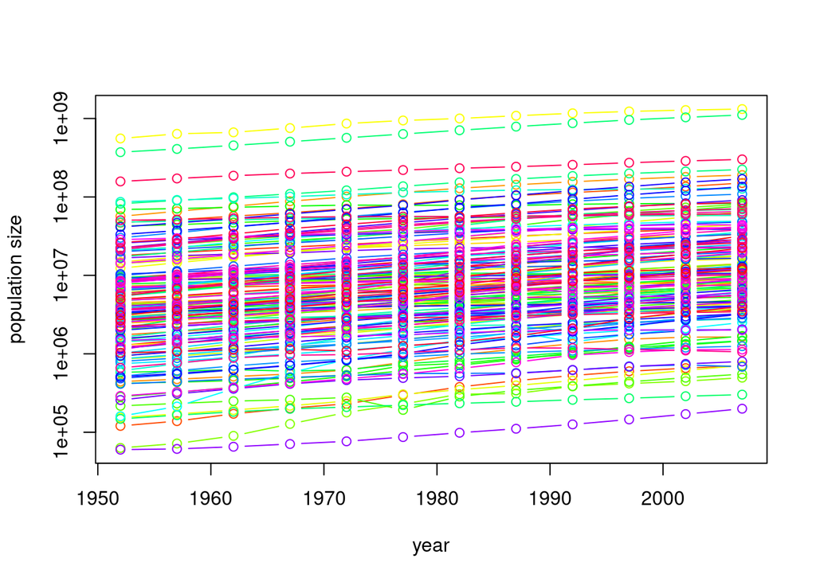

```r
unCountries <- unique(dat$country)
colz <- rainbow(length(unCountries))

tmp <- dat[which(dat$country == unCountries[1]), ]
plot(x=tmp$year, y=tmp$pop, log='y',
    xlab='year', ylab='population size',
    pch=16, type='b', col=colz[1],
    ylim=c(min(dat$pop), max(dat$pop)))

for(i in 2:length(unCountries)){
    tmp <- dat[which(dat$country == unCountries[i]), ]
    lines(x=tmp$year, y=tmp$pop, type='b', col=colz[i])

}
```

```r
# it's ugly, but the code is there.
```

Load the `who` data from dplyr (`data(who)` after you call `library(dplyr)`).

Get familiar with the data. Use joins on the data to make it so that you calculate the relationship (correlation) between positive pulmonary smear (sp) cases across all age groups and gdpPercap from the gapminder data for each country.

```r
library(plyr)
library(dplyr)
library(tidyr)
data(who)

spCounts <- dplyr::select(who, grep('sp', colnames(who)))
who$spCounts <- rowSums(spCounts, na.rm=TRUE)

ret <- left_join(dat, who, by=c('country','year'))

unConts <- unique(ret$country)
curz <- c()
for(i in 1:length(unConts)){
    tmp <- ret[which(ret$country == unConts[i]), ]
    curz[i] <- cor(tmp$spCounts, tmp$gdpPercap, use='pairwise.complete.obs')
}






# Ah, some of the data don't have enough information. So the dplyr approach below bonks on Bolivia. For loop above does not fall into that trap

#ret |>
#   group_by(country) |>
#   summarise(cor=cor(spCounts, gdpPercap, use='complete.obs'))
```